# Marketing Mix Modelling (MMM)

Case Study: FourTex

Rishi Ashok Kumar

September 10, 2025

> A tidy, documented MMM workflow you can knit end‑to‑end.  
> Data expected in the working directory as **`data_fourtex.csv`** with columns: `Google_Adwords, Facebook, TV, Radio, traffic` (weekly observations).

# 1 Setup

```r
# Core
library(tidyverse)
library(scales)
library(ggplot2)
```

```r
# Read data ---------------------------------------------------------------
stopifnot(file.exists("data_fourtex.csv"))
data <- readr::read_csv("data_fourtex.csv", show_col_types = FALSE)
```

```r
glimpse(data)
```

```
## Rows: 57
## Columns: 6
## $ week_beg       <chr> "06/07/2020", "13/07/2020", "20/07/2020", "27/07/2020",…
## $ Google_Adwords <dbl> 94017.2, 93634.5, 112239.4, 121250.3, 130470.9, 131955.…
## $ Facebook       <dbl> 82950, 66150, 94650, 96450, 114600, 119550, 106350, 116…
## $ TV             <dbl> 0, 0, 0, 0, 0, 0, 0, 0, 0, 0, 0, 0, 0, 0, 4341824, 0, 0…
## $ Radio          <dbl> 0, 0, 0, 0, 0, 0, 0, 0, 1298507, 0, 0, 0, 0, 0, 0, 0, 0…
## $ traffic        <dbl> 6719812, 6186229, 6790416, 7146957, 7815741, 8444791, 8…
```

```r
summary(data)
```

```
##    week_beg         Google_Adwords      Facebook            TV
##  Length:57          Min.   : 77074   Min.   : 53700   Min.   :      0
##  Class :character   1st Qu.:128108   1st Qu.: 82350   1st Qu.:      0
##  Mode  :character   Median :148203   Median : 96750   Median :      0
##                     Mean   :157887   Mean   :112932   Mean   : 729718
##                     3rd Qu.:180690   3rd Qu.:119550   3rd Qu.:      0
##                     Max.   :322622   Max.   :376650   Max.   :6693444
##      Radio            traffic
##  Min.   :      0   Min.   : 3995216
##  1st Qu.:      0   1st Qu.: 5449003
##  Median :      0   Median : 6464867
##  Mean   : 191914   Mean   : 6545933
##  3rd Qu.:      0   3rd Qu.: 7041649
##  Max.   :1514925   Max.   :13174892
```

```r
## Quick sanity checks

# Check for missing or negative values (spend should be >= 0)
colSums(is.na(data))
```

```
##       week_beg Google_Adwords       Facebook             TV          Radio
##              0              0              0              0              0
##        traffic
##              0
```

```r
summary(select(data, Google_Adwords, Facebook, TV, Radio, traffic) < 0)
```

```
##  Google_Adwords   Facebook           TV            Radio
##  Mode :logical   Mode :logical   Mode :logical   Mode :logical
##  FALSE:57        FALSE:57        FALSE:57        FALSE:57
##   traffic
##  Mode :logical
##  FALSE:57
```

```r
# Time series preparation

## We assume weekly data with 52 observations per year. The first observation is set to **2020, week 28** to mirror your original script. The exact calendar date is not critical for the model, but it helps for readable plots.

# Extract series as vectors
google_adwords <- data$Google_Adwords
facebook       <- data$Facebook
tv             <- data$TV
radio          <- data$Radio
traffic        <- data$traffic

# Build ts objects (weekly frequency)
google_adwords <- ts(google_adwords, frequency = 52, start = c(2020, 28))
facebook       <- ts(facebook,frequency = 52, start = c(2020, 28))
tv             <- ts(tv,frequency = 52, start = c(2020, 28))
radio.         <- ts(radio,frequency = 52, start = c(2020, 28))
traffic.       <- ts(traffic,frequency = 52, start = c(2020, 28))

online_total   <- google_adwords + facebook
offline_total  <- tv + radio
```

# 2 Visual inspection

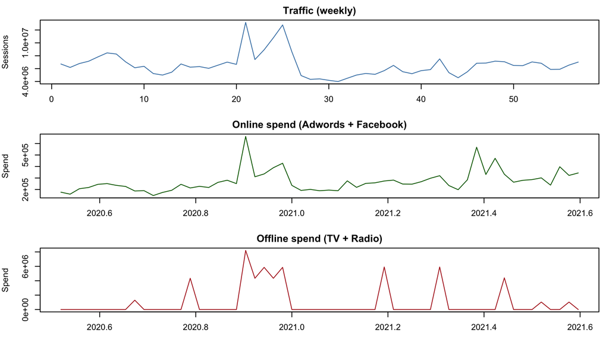

```r
par(mfrow = c(3,1), mar = c(3,4,2,1))
plot(traffic, type = "l", col = "steelblue", main = "Traffic (weekly)", ylab = "Sessions", xlab = "")
plot(online_total, col = "darkgreen", main = "Online spend (Adwords + Facebook)", ylab = "Spend", xlab = "")
plot(offline_total, col = "firebrick", main = "Offline spend (TV + Radio)", ylab = "Spend", xlab = "")
```

# 3 Media spending share

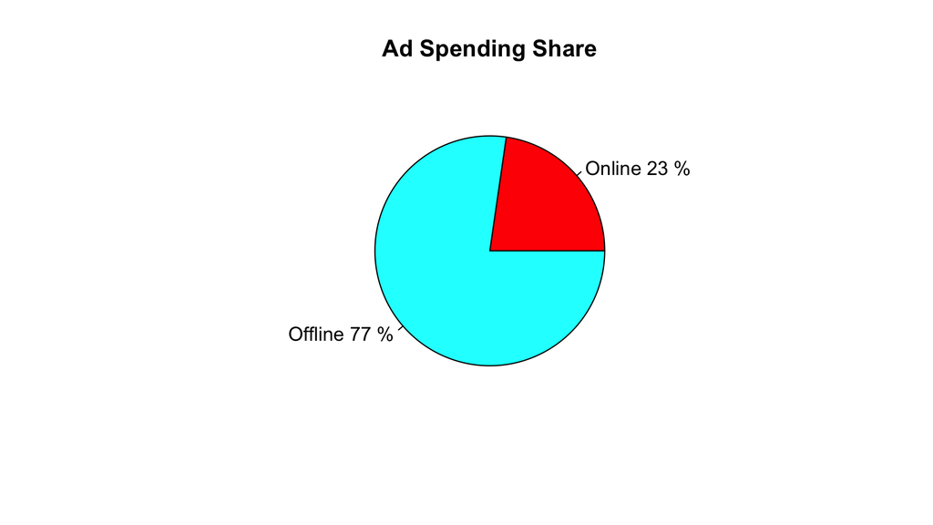

```r
### Media spending share
sum_online  <- sum(online_total)
sum_offline <- sum(offline_total)
total_spend <- sum_online + sum_offline

online_share  <- sum_online / total_spend
offline_share <- sum_offline / total_spend

# Pie chart for Media Spending Share
slices <- c(online_share, offline_share)
lbls   <- c("Online", "Offline")

# Add percentage labels
pct   <- round(slices * 100)
lbls  <- paste(lbls, pct, "%", sep=" ")

par(mfrow = c(1, 1))
pie(slices,
    labels = lbls,
    col = rainbow(length(lbls)),
    main = "Ad Spending Share")
```

# 4 Why log transformations?

## 4.1 Log Transformations in Marketing Mix Models

- Advertising often exhibits **diminishing returns**: each extra dollar spent drives less additional sales/traffic.
- The natural logarithm function, `log(x)`, captures this shape automatically: it rises quickly at first, then flattens out.
- Logging variables also helps **stabilize variance** and reduce skewness in the data.

## 4.2 Why do we add `+1`?

- `log(0)` is **undefined** (goes to negative infinity).
- Since marketing spend or impressions may contain **zero values** (e.g., weeks with no ads), we shift the data slightly:

  ```r
  log(x + 1)
  ```

- This ensures the log is always valid:
  - If `x = 0`, then `log(0+1) = 0`.
  - If `x > 0`, the shift has a very small effect.

## 4.3 How to interpret regression coefficients

1. **Log-Log model**
   - Model:
     $$\ln(Y) = \alpha + \beta \ln(X)$$
   - Interpretation:
     - **β = elasticity**
     - A 1% increase in $X$ leads to a **β% change in $Y$**.
     - Example: If β = 0.4, then a 1% increase in spend increases sales by 0.4%.
2. **Semi-log models**
   - **Log-linear (log Y only)**
     $$\ln(Y) = \alpha + \beta X$$
     - A 1-unit increase in $X$ changes $Y$ by $(e^{\beta} - 1)\times 100\%$.
     - Approximation: if β is small, then each unit of $X$ gives about $100 \times β\%$ change in $Y$.
   - **Linear-log (log X only)**
     $$Y = \alpha + \beta \ln(X)$$
     - A 1% increase in $X$ changes $Y$ by $\beta / 100$ units.
     - Captures diminishing returns in $X$, but keeps $Y$ in levels.

**Summary:**  
- **Log-log** is the most common in MMM because elasticity (%↔︎%) is intuitive.  
- **Semi-log** is useful when only one side grows nonlinearly.  
- Adding `+1` ensures zeros don’t break the log transformation.

## 4.4 What we’re predicting in this model

In our MMM, we **predict weekly web traffic** using last week’s traffic (to capture persistence) and the **same-week ad spend** in each channel. We estimate a **log–log** specification so the media coefficients can be read as **elasticities** (percent–percent effects):

$$\ln(\mathrm{Traffic}_t) \;=\; \beta_0
+ \beta_1 \ln(\mathrm{Traffic}_{t-1})
+ \beta_2 \ln(\mathrm{Adwords}_t)
+ \beta_3 \ln(\mathrm{Facebook}_t)
+ \beta_4 \ln(\mathrm{TV}_t)
+ \beta_5 \ln(\mathrm{Radio}_t)
+ \epsilon_t$$

**How to read it:** - $\beta_1$: **carryover/persistence** — how strongly last week’s traffic predicts this week’s. - $\beta_{2..5}$: **media elasticities** — a **1%** increase in that channel’s spend changes traffic by **$\beta\%$** (holding other factors constant). - $\beta_0$: **baseline log-traffic** when all predictors are at 1 (in practice, the intercept). - $\epsilon_t$: **random error**.

> *Implementation note:* in code we use `log(x + 1)` for media and traffic to handle zero spend/weeks gracefully while preserving the elasticity interpretation.

```r
# converting all the variable to logs
ln_google_adwords <- log(google_adwords + 1)
ln_facebook       <- log(facebook + 1)
ln_tv             <- log(tv + 1)
ln_radio          <- log(radio + 1)
ln_traffic        <- log(traffic + 1)

# Creating Lagged Traffic Variable
m <- 1  # one lag

# number of observations
n <- length(traffic)

# Build lagged variable
Lag1_ln_traffic <- c(rep(NA, m), ln_traffic[1:(n - m)])
```

```r
# Fit a Regression
options(scipen = 999)  # prevent scientific notation

ln_traffic <- ts(ln_traffic, frequency = 52, start = c(2020, 28))

regression1 <- lm(
  ln_traffic ~ Lag1_ln_traffic + ln_google_adwords + ln_facebook + ln_tv + ln_radio
)

# Show regression summary
summary(regression1)
```

```
##
## Call:
## lm(formula = ln_traffic ~ Lag1_ln_traffic + ln_google_adwords +
##     ln_facebook + ln_tv + ln_radio)
##
## Residuals:
##      Min       1Q   Median       3Q      Max
## -0.32118 -0.08169 -0.00214  0.08718  0.21416
##
## Coefficients:
##                   Estimate Std. Error t value      Pr(>|t|)
## (Intercept)       3.150739   1.498074   2.103       0.04050 *
## Lag1_ln_traffic   0.535935   0.076474   7.008 0.00000000583 ***
## ln_google_adwords 0.155433   0.089834   1.730       0.08976 .
## ln_facebook       0.193668   0.056041   3.456       0.00113 **
## ln_tv             0.004569   0.004282   1.067       0.29107
## ln_radio          0.006963   0.004046   1.721       0.09147 .
## ---
## Signif. codes:  0 '***' 0.001 '**' 0.01 '*' 0.05 '.' 0.1 ' ' 1
##
## Residual standard error: 0.1252 on 50 degrees of freedom
##   (1 observation deleted due to missingness)
## Multiple R-squared:  0.7578, Adjusted R-squared:  0.7336
## F-statistic: 31.29 on 5 and 50 DF,  p-value: 0.0000000000000273
```

# 5 Actual vs fitted

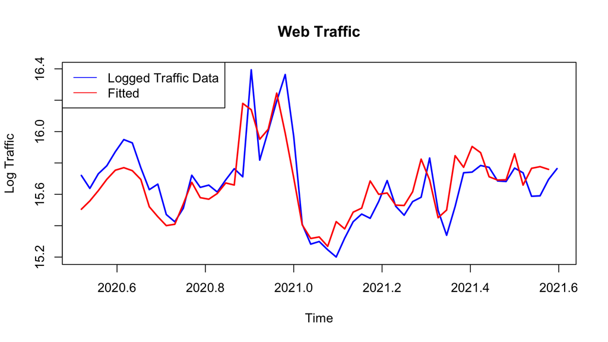

```r
# Create fitted traffic as a time series
fitted_traffic <- ts(regression1$fitted.values, frequency = 52, start = c(2020, 28))

# Plot actual vs fitted
plot(ln_traffic, type = "l", col = "blue", lwd = 2,
     main = "Web Traffic", ylab = "Log Traffic", xlab = "Time")

lines(fitted_traffic, col = "red", lwd = 2)

legend("topleft",
       lty = 1, col = c("blue", "red"),
       legend = c("Logged Traffic Data", "Fitted"))
```

# 6 7) Contributions & ROI (TROMI)

We convert elasticities to **unit effects** around the average level to estimate **contribution to traffic** and **traffic ROI**:
$$\frac{dY}{dX} \approx \beta \cdot \frac{\bar{Y}}{\bar{X}} \quad
\Rightarrow \quad
\text{contribution} \approx \theta \times \text{spend}$$

```r
#retrieve model coefficients

beta_adwords <- summary(regression1)$coefficients[3,1] #row three column one
beta_facebook <- summary(regression1)$coefficients[4,1]
beta_tv <- summary(regression1)$coefficients[5,1]
beta_radio <- summary(regression1)$coefficients[6,1]

# calculate the baseline average traffic
avg_traffic <- mean(traffic)

# calculate the baseline average advertising spending for each media:
avg_adwords <- mean(google_adwords)
avg_facebook <- mean(facebook)
avg_tv <- mean(tv)
avg_radio <- mean(radio)

# Calculate the unit effect
theta_adwords <- beta_adwords * (avg_traffic / avg_adwords)
theta_facebook <- beta_facebook * (avg_traffic / avg_facebook)
theta_tv <- beta_tv * (avg_traffic / avg_tv)
theta_radio <- beta_radio * (avg_traffic / avg_radio)

# Display results
theta_adwords
```

```
## [1] 6.444173
```

```r
theta_facebook
```

```
## [1] 11.22571
```

```r
theta_tv
```

```
## [1] 0.04098557
```

```r
theta_radio
```

```
## [1] 0.2374893
```

```r
# How much traffic did we get thanks to TV, Adwords, etc.?

# Total spend for each channel
sum_adwords  <- sum(google_adwords)
sum_facebook <- sum(facebook)
sum_tv       <- sum(tv)
sum_radio    <- sum(radio)

# Each media's contribution to traffic
adwords_contribution  <- theta_adwords  * sum_adwords
facebook_contribution <- theta_facebook * sum_facebook
tv_contribution       <- theta_tv       * sum_tv
radio_contribution    <- theta_radio    * sum_radio
```

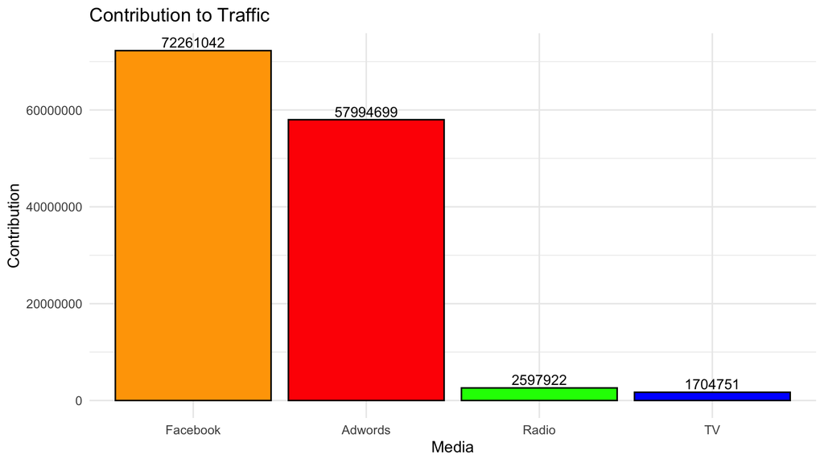

```r
# Barplot information
media_contribution <- c(adwords_contribution, facebook_contribution,
                        tv_contribution, radio_contribution)

# Round contributions to whole numbers
media_contribution <- round(media_contribution, digits = 0)

# Media names
media_names <- c("Adwords", "Facebook", "TV", "Radio")

# Create data frame
df <- data.frame(media_names, media_contribution)

# Barplot
bar_plot <- ggplot(data = df, aes(x = media_names, y = media_contribution)) +
  geom_bar(stat = "identity", color = "black",
           fill = c("red", "orange", "blue", "green")) +
  geom_text(aes(label = media_contribution),
            vjust = -0.3, size = 3.5) +
  labs(title = "Contribution to Traffic",
       x = "Media", y = "Contribution") +
  theme_minimal()

# Change the order of the bars
bar_plot + scale_x_discrete(limits = c("Facebook", "Adwords", "Radio", "TV"))
```

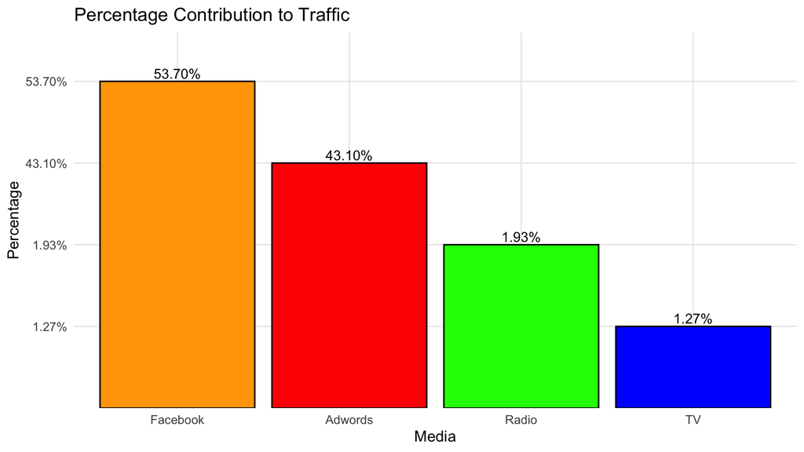

```r
# Total contribution from all media
allmedia_contribution <- adwords_contribution + facebook_contribution +
                         tv_contribution + radio_contribution

# Percentage contributions
adwords_pct  <- adwords_contribution  / allmedia_contribution
facebook_pct <- facebook_contribution / allmedia_contribution
tv_pct       <- tv_contribution       / allmedia_contribution
radio_pct    <- radio_contribution    / allmedia_contribution

# Put into a vector
pct_contribution <- c(adwords_pct, facebook_pct, tv_pct, radio_pct)

# Convert to percentage format
pct_contribution <- percent(pct_contribution)

# Media names
media_names <- c("Adwords", "Facebook", "TV", "Radio")

# Data frame
df2 <- data.frame(media_names, pct_contribution)

# Barplot for percentage contributions
bar_plot_pct <- ggplot(data = df2, aes(x = media_names, y = pct_contribution)) +
  geom_bar(stat = "identity", color = "black",
           fill = c("red", "orange", "blue", "green")) +
  geom_text(aes(label = pct_contribution),
            vjust = -0.3, size = 3.5) +
  labs(title = "Percentage Contribution to Traffic",
       x = "Media", y = "Percentage") +
  theme_minimal()

# Change the order of the bars
bar_plot_pct + scale_x_discrete(limits = c("Facebook", "Adwords", "Radio", "TV"))
```

```r
# Calculate the cost of each media
cost_adwords  <- sum(google_adwords)
cost_facebook <- sum(facebook)
cost_tv       <- sum(tv)
cost_radio    <- sum(radio)

# Total cost
cost_total <- cost_adwords + cost_facebook + cost_tv + cost_radio

# Vector of costs
cost <- c(cost_adwords, cost_facebook, cost_tv, cost_radio)
cost <- round(cost, digits = 0)

# Traffic Contribution vs Cost Data Frame
df3 <- data.frame(
  traf_cost = rep(c("Traffic", "Cost"), each = 4),
  media_names = rep(c("Adwords", "Facebook", "TV", "Radio"), 2),
  values = c(media_contribution, cost)
)
```

# 7 Actual vs **optimal** budget split (elasticity rule)

A simple rule-of-thumb allocates budget **proportional to elasticities** (assuming equal prices per traffic unit and no constraints).

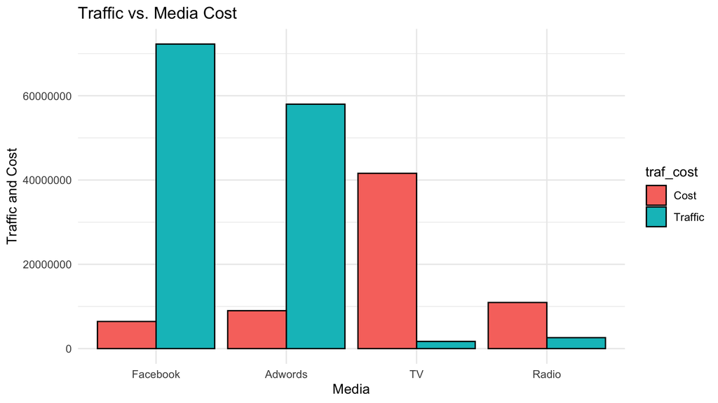

```r
# Grouped barplot: Traffic vs Cost
bar_plot3 <- ggplot(data = df3, aes(x = media_names, y = values, fill = traf_cost)) +
  geom_bar(stat = "identity", color = "black", position = position_dodge()) +
  labs(title = "Traffic vs. Media Cost",
       x = "Media", y = "Traffic and Cost") +
  theme_minimal() +
  scale_x_discrete(limits = c("Facebook", "Adwords", "TV", "Radio"))

# Display the plot
bar_plot3
```

```r
# Calculate the traffic return (TROMI) for each media
roi_adwords  <- adwords_contribution  / cost_adwords
roi_facebook <- facebook_contribution / cost_facebook
roi_tv       <- tv_contribution       / cost_tv
roi_radio    <- radio_contribution    / cost_radio

# Put ROI values into a vector
roi <- c(roi_adwords, roi_facebook, roi_tv, roi_radio)

# Round ROI values
roi <- round(roi, digits = 2)

# Create data frame
media_names <- c("Adwords", "Facebook", "TV", "Radio")
df4 <- data.frame(media_names, roi)

# Preview
head(df4)
```

|  | media_names | roi |
| --- | --- | --- |
| 1 | Adwords | 6.44 |
| 2 | Facebook | 11.23 |
| 3 | TV | 0.04 |
| 4 | Radio | 0.24 |

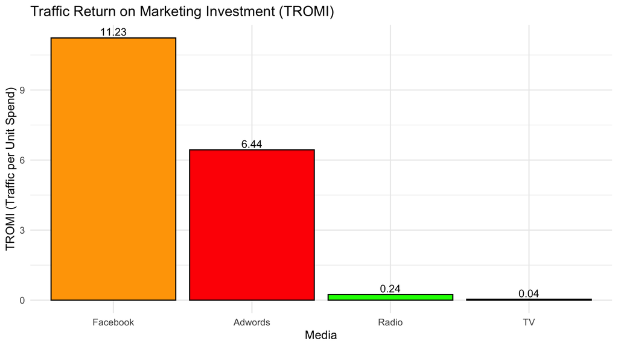

```r
# TROMI bar plot
bar_plot4 <- ggplot(data = df4, aes(x = media_names, y = roi)) +
  geom_bar(stat = "identity", color = "black",
           fill = c("red", "orange", "blue", "green")) +
  geom_text(aes(label = roi),
            vjust = -0.3, size = 3.5) +
  labs(title = "Traffic Return on Marketing Investment (TROMI)",
       x = "Media", y = "TROMI (Traffic per Unit Spend)") +
  theme_minimal() +
  scale_x_discrete(limits = c("Facebook", "Adwords", "Radio", "TV"))

# Display plot
bar_plot4
```

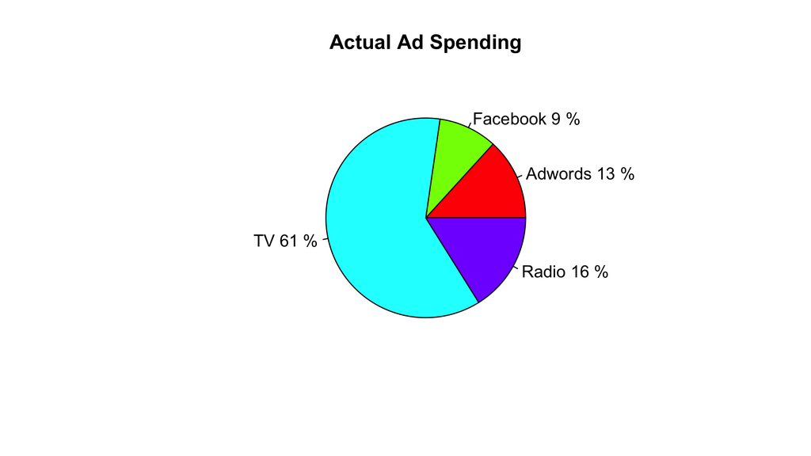

```r
# Actual Budget Spending Shares
costshare_adwords  <- cost_adwords  / cost_total
costshare_facebook <- cost_facebook / cost_total
costshare_tv       <- cost_tv       / cost_total
costshare_radio    <- cost_radio    / cost_total

# Input for the pie chart
slices_actual <- c(costshare_adwords, costshare_facebook, costshare_tv, costshare_radio)
lbls_actual   <- c("Adwords", "Facebook", "TV", "Radio")

# Add percentages to labels
pct_actual   <- round(slices_actual * 100)
lbls_actual  <- paste(lbls_actual, pct_actual, "%")

# Pie chart
pie(slices_actual,
    labels = lbls_actual,
    col = rainbow(length(lbls_actual)),
    main = "Actual Ad Spending")
```

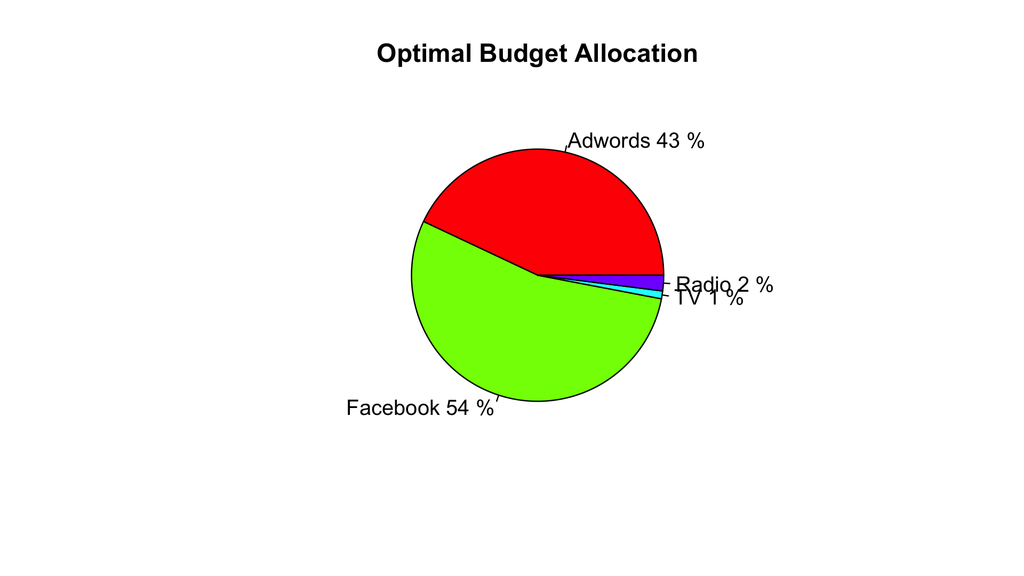

```r
# The sum of all media elasticities
beta_allmedia <- beta_adwords + beta_facebook + beta_tv + beta_radio

# Optimal resource allocation (budget share by elasticity)
optim_adwords  <- beta_adwords  / beta_allmedia
optim_facebook <- beta_facebook / beta_allmedia
optim_tv       <- beta_tv       / beta_allmedia
optim_radio    <- beta_radio    / beta_allmedia

# Pie-chart ingredients for optimal allocation
slices_optim <- c(optim_adwords, optim_facebook, optim_tv, optim_radio)
slices_optim <- round(slices_optim, digits = 2)

lbls_optim <- c("Adwords", "Facebook", "TV", "Radio")
pct_optim  <- round(slices_optim * 100)

# Add percentage labels
lbls_optim <- paste(lbls_optim, pct_optim, "%")

# Pie chart
pie(slices_optim,
    labels = lbls_optim,
    col = rainbow(length(lbls_optim)),
    main = "Optimal Budget Allocation")
```